# Cyclist Analysis

Braden Leonard

July 16, 2020

## Cyclist Full Year Analysis

### This is the analysis for the Google Data Analytics Certificate capstone Project

The scenario presented was the marketing team from Cyclist, a bike-sharing company in Chicago, wants to maximize their annual memberships. They wanted to understand how casual riders and membership riders use the bike share differently. Their goal is to learn how to convert casual riders to annual members. I will follow the Ask, Prepare, Process, Analyze, Share and Act steps to the data analysis.

## Ask

Now if this were an actual business task, I would ask the questions to their representatives to better understand what they are hoping to get presented to them, what metrics we are working with(possible errors), and if they would like suggestions. Since this is a capstone project, we will have to try and answer these questions ourselves.

## Prepare

They provided us a divvy-data bases of all their trip data since they started in 2014. I since we require the most recent data for our analysis to be relevant, We loaded the most recent data(2019-2020).

Most of these files are too large for programs like excel, so R is the perfect fit for cleaning and manipulating this large dataset.

## Process

To start we will need to install the necessary packages:

```r
#install.packages("tidyverse")
#("lubridate")
```

We will then have to load these packages:

```r
library(tidyverse)
library(lubridate)
```

Now we have to import the last 4 quarters for data to be cleaned.

```r
q1 <- read.csv("Divvy_Trips_2019_Q2.csv")
q2 <- read.csv("Divvy_Trips_2019_Q3.csv")
q3 <- read.csv("Divvy_Trips_2019_Q4.csv")
q4 <- read.csv("Divvy_Trips_2020_Q1.csv")
```

Now lets take a look at these data sets so see how they are similar or different.

```r
colnames(q1)
```

```
##  [1] "X01...Rental.Details.Rental.ID"
##  [2] "X01...Rental.Details.Local.Start.Time"
##  [3] "X01...Rental.Details.Local.End.Time"
##  [4] "X01...Rental.Details.Bike.ID"
##  [5] "X01...Rental.Details.Duration.In.Seconds.Uncapped"
##  [6] "X03...Rental.Start.Station.ID"
##  [7] "X03...Rental.Start.Station.Name"
##  [8] "X02...Rental.End.Station.ID"
##  [9] "X02...Rental.End.Station.Name"
## [10] "User.Type"
## [11] "Member.Gender"
## [12] "X05...Member.Details.Member.Birthday.Year"
```

```r
colnames(q2)
```

```
##  [1] "trip_id"           "start_time"        "end_time"
##  [4] "bikeid"            "tripduration"      "from_station_id"
##  [7] "from_station_name" "to_station_id"     "to_station_name"
## [10] "usertype"          "gender"            "birthyear"
```

```r
colnames(q3)
```

```
##  [1] "trip_id"           "start_time"        "end_time"
##  [4] "bikeid"            "tripduration"      "from_station_id"
##  [7] "from_station_name" "to_station_id"     "to_station_name"
## [10] "usertype"          "gender"            "birthyear"
```

```r
colnames(q4)
```

```
##  [1] "ride_id"            "rideable_type"      "started_at"
##  [4] "ended_at"           "start_station_name" "start_station_id"
##  [7] "end_station_name"   "end_station_id"     "start_lat"
## [10] "start_lng"          "end_lat"            "end_lng"
## [13] "member_casual"
```

### Cleaning

Looks like the naming for each column is not consistent and will need to be changed if we want to merge these into one data set. We will use q4 (in this case the first quarter of 2020) as a baseline for their column names.

```r
(q1 <- rename(q1
              ,ride_id=X01...Rental.Details.Rental.ID
              ,rideable_type=X01...Rental.Details.Bike.ID
              ,started_at=X01...Rental.Details.Local.Start.Time
              ,ended_at= X01...Rental.Details.Local.End.Time
              ,start_station_name=X03...Rental.Start.Station.Name
              ,start_station_id=X03...Rental.Start.Station.ID
              ,end_station_name=X02...Rental.End.Station.Name
              ,end_station_id=X02...Rental.End.Station.ID
              ,member_casual=User.Type))

(q2 <- rename(q2
              ,ride_id=trip_id
              ,rideable_type=bikeid
              ,started_at=start_time
              ,ended_at=end_time
              ,start_station_name=from_station_name
              ,start_station_id=from_station_id
              ,end_station_name=to_station_name
              ,end_station_id=to_station_id
              ,member_casual=usertype))

(q3 <- rename(q3
              ,ride_id=trip_id
              ,rideable_type=bikeid
              ,started_at=start_time
              ,ended_at=end_time
              ,start_station_name=from_station_name
              ,start_station_id=from_station_id
              ,end_station_name=to_station_name
              ,end_station_id=to_station_id
              ,member_casual=usertype))
```

```r
colnames(q1)
```

```
##  [1] "ride_id"
##  [2] "started_at"
##  [3] "ended_at"
##  [4] "rideable_type"
##  [5] "X01...Rental.Details.Duration.In.Seconds.Uncapped"
##  [6] "start_station_id"
##  [7] "start_station_name"
##  [8] "end_station_id"
##  [9] "end_station_name"
## [10] "member_casual"
## [11] "Member.Gender"
## [12] "X05...Member.Details.Member.Birthday.Year"
```

```r
colnames(q2)
```

```
##  [1] "ride_id"            "started_at"         "ended_at"
##  [4] "rideable_type"      "tripduration"       "start_station_id"
##  [7] "start_station_name" "end_station_id"     "end_station_name"
## [10] "member_casual"      "gender"             "birthyear"
```

```r
colnames(q3)
```

```
##  [1] "ride_id"            "started_at"         "ended_at"
##  [4] "rideable_type"      "tripduration"       "start_station_id"
##  [7] "start_station_name" "end_station_id"     "end_station_name"
## [10] "member_casual"      "gender"             "birthyear"
```

```r
colnames(q4)
```

```
##  [1] "ride_id"            "rideable_type"      "started_at"
##  [4] "ended_at"           "start_station_name" "start_station_id"
##  [7] "end_station_name"   "end_station_id"     "start_lat"
## [10] "start_lng"          "end_lat"            "end_lng"
## [13] "member_casual"
```

Now lets inspect these dataframe to see what columns will be useful

```r
str(q1)
```

```
## 'data.frame':    1108163 obs. of  12 variables:
##  $ ride_id                                          : int  22178529 22178530 22178531 22178532 22178533 22178534 22178535 22178536 22178537 22178538 ...
##  $ started_at                                       : chr  "2019-04-01 00:02:22" "2019-04-01 00:03:02" "2019-04-01 00:11:07" "2019-04-01 00:13:01" ...
##  $ ended_at                                         : chr  "2019-04-01 00:09:48" "2019-04-01 00:20:30" "2019-04-01 00:15:19" "2019-04-01 00:18:58" ...
##  $ rideable_type                                    : int  6251 6226 5649 4151 3270 3123 6418 4513 3280 5534 ...
##  $ X01...Rental.Details.Duration.In.Seconds.Uncapped: chr  "446.0" "1,048.0" "252.0" "357.0" ...
##  $ start_station_id                                 : int  81 317 283 26 202 420 503 260 211 211 ...
##  $ start_station_name                               : chr  "Daley Center Plaza" "Wood St & Taylor St" "LaSalle St & Jackson Blvd" "McClurg Ct & Illinois St" ...
##  $ end_station_id                                   : int  56 59 174 133 129 426 500 499 211 211 ...
##  $ end_station_name                                 : chr  "Desplaines St & Kinzie St" "Wabash Ave & Roosevelt Rd" "Canal St & Madison St" "Kingsbury St & Kinzie St" ...
##  $ member_casual                                    : chr  "Subscriber" "Subscriber" "Subscriber" "Subscriber" ...
##  $ Member.Gender                                    : chr  "Male" "Female" "Male" "Male" ...
##  $ X05...Member.Details.Member.Birthday.Year        : int  1975 1984 1990 1993 1992 1999 1969 1991 NA NA ...
```

```r
str(q2)
```

```
## 'data.frame':    1640718 obs. of  12 variables:
##  $ ride_id           : int  23479388 23479389 23479390 23479391 23479392 23479393 23479394 23479395 23479396 23479397 ...
##  $ started_at        : chr  "2019-07-01 00:00:27" "2019-07-01 00:01:16" "2019-07-01 00:01:48" "2019-07-01 00:02:07" ...
##  $ ended_at          : chr  "2019-07-01 00:20:41" "2019-07-01 00:18:44" "2019-07-01 00:27:42" "2019-07-01 00:27:10" ...
##  $ rideable_type     : int  3591 5353 6180 5540 6014 4941 3770 5442 2957 6091 ...
##  $ tripduration      : chr  "1,214.0" "1,048.0" "1,554.0" "1,503.0" ...
##  $ start_station_id  : int  117 381 313 313 168 300 168 313 43 43 ...
##  $ start_station_name: chr  "Wilton Ave & Belmont Ave" "Western Ave & Monroe St" "Lakeview Ave & Fullerton Pkwy" "Lakeview Ave & Fullerton Pkwy" ...
##  $ end_station_id    : int  497 203 144 144 62 232 62 144 195 195 ...
##  $ end_station_name  : chr  "Kimball Ave & Belmont Ave" "Western Ave & 21st St" "Larrabee St & Webster Ave" "Larrabee St & Webster Ave" ...
##  $ member_casual     : chr  "Subscriber" "Customer" "Customer" "Customer" ...
##  $ gender            : chr  "Male" "" "" "" ...
##  $ birthyear         : int  1992 NA NA NA NA 1990 NA NA NA NA ...
```

```r
str(q3)
```

```
## 'data.frame':    704054 obs. of  12 variables:
##  $ ride_id           : int  25223640 25223641 25223642 25223643 25223644 25223645 25223646 25223647 25223648 25223649 ...
##  $ started_at        : chr  "2019-10-01 00:01:39" "2019-10-01 00:02:16" "2019-10-01 00:04:32" "2019-10-01 00:04:32" ...
##  $ ended_at          : chr  "2019-10-01 00:17:20" "2019-10-01 00:06:34" "2019-10-01 00:18:43" "2019-10-01 00:43:43" ...
##  $ rideable_type     : int  2215 6328 3003 3275 5294 1891 1061 1274 6011 2957 ...
##  $ tripduration      : chr  "940.0" "258.0" "850.0" "2,350.0" ...
##  $ start_station_id  : int  20 19 84 313 210 156 84 156 156 336 ...
##  $ start_station_name: chr  "Sheffield Ave & Kingsbury St" "Throop (Loomis) St & Taylor St" "Milwaukee Ave & Grand Ave" "Lakeview Ave & Fullerton Pkwy" ...
##  $ end_station_id    : int  309 241 199 290 382 226 142 463 463 336 ...
##  $ end_station_name  : chr  "Leavitt St & Armitage Ave" "Morgan St & Polk St" "Wabash Ave & Grand Ave" "Kedzie Ave & Palmer Ct" ...
##  $ member_casual     : chr  "Subscriber" "Subscriber" "Subscriber" "Subscriber" ...
##  $ gender            : chr  "Male" "Male" "Female" "Male" ...
##  $ birthyear         : int  1987 1998 1991 1990 1987 1994 1991 1995 1993 NA ...
```

```r
str(q4)
```

```
## 'data.frame':    426887 obs. of  13 variables:
##  $ ride_id           : chr  "EACB19130B0CDA4A" "8FED874C809DC021" "789F3C21E472CA96" "C9A388DAC6ABF313" ...
##  $ rideable_type     : chr  "docked_bike" "docked_bike" "docked_bike" "docked_bike" ...
##  $ started_at        : chr  "2020-01-21 20:06:59" "2020-01-30 14:22:39" "2020-01-09 19:29:26" "2020-01-06 16:17:07" ...
##  $ ended_at          : chr  "2020-01-21 20:14:30" "2020-01-30 14:26:22" "2020-01-09 19:32:17" "2020-01-06 16:25:56" ...
##  $ start_station_name: chr  "Western Ave & Leland Ave" "Clark St & Montrose Ave" "Broadway & Belmont Ave" "Clark St & Randolph St" ...
##  $ start_station_id  : int  239 234 296 51 66 212 96 96 212 38 ...
##  $ end_station_name  : chr  "Clark St & Leland Ave" "Southport Ave & Irving Park Rd" "Wilton Ave & Belmont Ave" "Fairbanks Ct & Grand Ave" ...
##  $ end_station_id    : int  326 318 117 24 212 96 212 212 96 100 ...
##  $ start_lat         : num  42 42 41.9 41.9 41.9 ...
##  $ start_lng         : num  -87.7 -87.7 -87.6 -87.6 -87.6 ...
##  $ end_lat           : num  42 42 41.9 41.9 41.9 ...
##  $ end_lng           : num  -87.7 -87.7 -87.7 -87.6 -87.6 ...
##  $ member_casual     : chr  "member" "member" "member" "member" ...
```

Need to convert ride_id and rideable_id to characters so they can stack correctly.

```r
q4<-  mutate(q4, ride_id = as.character(ride_id)
                   ,rideable_type = as.character(rideable_type))
q3<-  mutate(q3, ride_id = as.character(ride_id)
                   ,rideable_type = as.character(rideable_type))
q2<-  mutate(q2, ride_id = as.character(ride_id)
                   ,rideable_type = as.character(rideable_type))
q1<-  mutate(q1, ride_id = as.character(ride_id)
                   ,rideable_type= as.character(rideable_type))
```

Now lets stack the data frames into one so it is easy to clean

```r
all_trips <- bind_rows(q1,q2,q3,q4)
```

Lets take a look at all the columns in our new data frame

```r
colnames(all_trips)
```

```
##  [1] "ride_id"
##  [2] "started_at"
##  [3] "ended_at"
##  [4] "rideable_type"
##  [5] "X01...Rental.Details.Duration.In.Seconds.Uncapped"
##  [6] "start_station_id"
##  [7] "start_station_name"
##  [8] "end_station_id"
##  [9] "end_station_name"
## [10] "member_casual"
## [11] "Member.Gender"
## [12] "X05...Member.Details.Member.Birthday.Year"
## [13] "tripduration"
## [14] "gender"
## [15] "birthyear"
## [16] "start_lat"
## [17] "start_lng"
## [18] "end_lat"
## [19] "end_lng"
```

Looks great we just need to trim the columns that are not very useful for us. Lets clean it up

```r
all_trips <- all_trips %>%
  select(-c(start_lat, start_lng, end_lat, end_lng, birthyear, gender, tripduration, Member.Gender, X05...Member.Details.Member.Birthday.Year, X01...Rental.Details.Duration.In.Seconds.Uncapped ))
```

Now lets check the data frame

```r
colnames(all_trips)
```

```
## [1] "ride_id"            "started_at"         "ended_at"
## [4] "rideable_type"      "start_station_id"   "start_station_name"
## [7] "end_station_id"     "end_station_name"   "member_casual"
```

Great,we now have one data frame with all columns useful and we can now start to clean the data.

```r
nrow(all_trips)
```

```
## [1] 3879822
```

We have lots of entries, that is great our sample size is large!

```r
dim(all_trips)
```

```
## [1] 3879822       9
```

Lets check the data types to make sure they are what we want before calculation.

```r
str(all_trips)
```

```
## 'data.frame':    3879822 obs. of  9 variables:
##  $ ride_id           : chr  "22178529" "22178530" "22178531" "22178532" ...
##  $ started_at        : chr  "2019-04-01 00:02:22" "2019-04-01 00:03:02" "2019-04-01 00:11:07" "2019-04-01 00:13:01" ...
##  $ ended_at          : chr  "2019-04-01 00:09:48" "2019-04-01 00:20:30" "2019-04-01 00:15:19" "2019-04-01 00:18:58" ...
##  $ rideable_type     : chr  "6251" "6226" "5649" "4151" ...
##  $ start_station_id  : int  81 317 283 26 202 420 503 260 211 211 ...
##  $ start_station_name: chr  "Daley Center Plaza" "Wood St & Taylor St" "LaSalle St & Jackson Blvd" "McClurg Ct & Illinois St" ...
##  $ end_station_id    : int  56 59 174 133 129 426 500 499 211 211 ...
##  $ end_station_name  : chr  "Desplaines St & Kinzie St" "Wabash Ave & Roosevelt Rd" "Canal St & Madison St" "Kingsbury St & Kinzie St" ...
##  $ member_casual     : chr  "Subscriber" "Subscriber" "Subscriber" "Subscriber" ...
```

```r
summary(all_trips)
```

```
##    ride_id           started_at          ended_at         rideable_type
##  Length:3879822     Length:3879822     Length:3879822     Length:3879822
##  Class :character   Class :character   Class :character   Class :character
##  Mode  :character   Mode  :character   Mode  :character   Mode  :character
##
##
##
##
##  start_station_id start_station_name end_station_id  end_station_name
##  Min.   :  1.0    Length:3879822     Min.   :  1.0   Length:3879822
##  1st Qu.: 77.0    Class :character   1st Qu.: 77.0   Class :character
##  Median :174.0    Mode  :character   Median :174.0   Mode  :character
##  Mean   :202.9                       Mean   :203.8
##  3rd Qu.:291.0                       3rd Qu.:291.0
##  Max.   :675.0                       Max.   :675.0
##                                      NA's   :1
##  member_casual
##  Length:3879822
##  Class :character
##  Mode  :character
##
##
##
##
```

Lots of interesting things to consider.

We will have to add columns to the data frame to find things like trip duration, day of the week etc.

First lets see a table of values from the member_casual column

```r
table(all_trips$member_casual)
```

```
##
##     casual   Customer     member Subscriber
##      48480     857474     378407    2595461
```

4 different entries. Easy fix. Since the conversations with Cyclist they referred to the different types of customers as casual and members. So we will change Subscriber to member and Customer to casual

```r
all_trips <- all_trips %>%
  mutate(member_casual= recode(member_casual
                               ,"Subscriber"="member"
                               ,"Customer"="casual"))
```

Lets check to see if it changed

```r
table(all_trips$member_casual)
```

```
##
##  casual  member
##  905954 2973868
```

Great! Now there is only two different types of customers, easy for comparing the two.

Now lets add columns for date, month, day,and year for each ride.

```r
all_trips$date <- as.Date(all_trips$started_at)
all_trips$month <- format(as.Date(all_trips$date), "%m")
all_trips$day <- format(as.Date(all_trips$date), "%d")
all_trips$year <- format(as.Date(all_trips$date), "%Y")
all_trips$day_of_week <- format(as.Date(all_trips$date), "%A")
```

Lets take a quick look to see how it looks.

```r
head(all_trips)
```

|  | ride_id | started_at | ended_at | rideable_type | start_station_id | start_station_name | end_station_id | end_station_name | member_casual | date | month | day | year | day_of_week |
| --- | --- | --- | --- | --- | --- | --- | --- | --- | --- | --- | --- | --- | --- | --- |
| 1 | 22178529 | 2019-04-01 00:02:22 | 2019-04-01 00:09:48 | 6251 | 81 | Daley Center Plaza | 56 | Desplaines St & Kinzie St | member | 2019-04-01 | 04 | 01 | 2019 | Monday |
| 2 | 22178530 | 2019-04-01 00:03:02 | 2019-04-01 00:20:30 | 6226 | 317 | Wood St & Taylor St | 59 | Wabash Ave & Roosevelt Rd | member | 2019-04-01 | 04 | 01 | 2019 | Monday |
| 3 | 22178531 | 2019-04-01 00:11:07 | 2019-04-01 00:15:19 | 5649 | 283 | LaSalle St & Jackson Blvd | 174 | Canal St & Madison St | member | 2019-04-01 | 04 | 01 | 2019 | Monday |
| 4 | 22178532 | 2019-04-01 00:13:01 | 2019-04-01 00:18:58 | 4151 | 26 | McClurg Ct & Illinois St | 133 | Kingsbury St & Kinzie St | member | 2019-04-01 | 04 | 01 | 2019 | Monday |
| 5 | 22178533 | 2019-04-01 00:19:26 | 2019-04-01 00:36:13 | 3270 | 202 | Halsted St & 18th St | 129 | Blue Island Ave & 18th St | member | 2019-04-01 | 04 | 01 | 2019 | Monday |
| 6 | 22178534 | 2019-04-01 00:19:39 | 2019-04-01 00:23:56 | 3123 | 420 | Ellis Ave & 55th St | 426 | Ellis Ave & 60th St | member | 2019-04-01 | 04 | 01 | 2019 | Monday |

Now lets add a ride length column

```r
all_trips$ride_length <- difftime(all_trips$ended_at, all_trips$started_at)
```

Now lets take a look at data types

```r
str(all_trips)
```

```
## 'data.frame':    3879822 obs. of  15 variables:
##  $ ride_id           : chr  "22178529" "22178530" "22178531" "22178532" ...
##  $ started_at        : chr  "2019-04-01 00:02:22" "2019-04-01 00:03:02" "2019-04-01 00:11:07" "2019-04-01 00:13:01" ...
##  $ ended_at          : chr  "2019-04-01 00:09:48" "2019-04-01 00:20:30" "2019-04-01 00:15:19" "2019-04-01 00:18:58" ...
##  $ rideable_type     : chr  "6251" "6226" "5649" "4151" ...
##  $ start_station_id  : int  81 317 283 26 202 420 503 260 211 211 ...
##  $ start_station_name: chr  "Daley Center Plaza" "Wood St & Taylor St" "LaSalle St & Jackson Blvd" "McClurg Ct & Illinois St" ...
##  $ end_station_id    : int  56 59 174 133 129 426 500 499 211 211 ...
##  $ end_station_name  : chr  "Desplaines St & Kinzie St" "Wabash Ave & Roosevelt Rd" "Canal St & Madison St" "Kingsbury St & Kinzie St" ...
##  $ member_casual     : chr  "member" "member" "member" "member" ...
##  $ date              : Date, format: "2019-04-01" "2019-04-01" ...
##  $ month             : chr  "04" "04" "04" "04" ...
##  $ day               : chr  "01" "01" "01" "01" ...
##  $ year              : chr  "2019" "2019" "2019" "2019" ...
##  $ day_of_week       : chr  "Monday" "Monday" "Monday" "Monday" ...
##  $ ride_length       : 'difftime' num  446 1048 252 357 ...
##   ..- attr(*, "units")= chr "secs"
```

```r
is.factor(all_trips$ride_length)
```

```
## [1] FALSE
```

```r
all_trips$ride_length <- as.numeric(as.character(all_trips$ride_length))
```

```r
is.numeric(all_trips$ride_length)
```

```
## [1] TRUE
```

Lets check a summary again.

```r
summary(all_trips)
```

```
##    ride_id           started_at          ended_at         rideable_type
##  Length:3879822     Length:3879822     Length:3879822     Length:3879822
##  Class :character   Class :character   Class :character   Class :character
##  Mode  :character   Mode  :character   Mode  :character   Mode  :character
##
##
##
##
##  start_station_id start_station_name end_station_id  end_station_name
##  Min.   :  1.0    Length:3879822     Min.   :  1.0   Length:3879822
##  1st Qu.: 77.0    Class :character   1st Qu.: 77.0   Class :character
##  Median :174.0    Mode  :character   Median :174.0   Mode  :character
##  Mean   :202.9                       Mean   :203.8
##  3rd Qu.:291.0                       3rd Qu.:291.0
##  Max.   :675.0                       Max.   :675.0
##                                      NA's   :1
##  member_casual           date               month               day
##  Length:3879822     Min.   :2019-04-01   Length:3879822     Length:3879822
##  Class :character   1st Qu.:2019-06-23   Class :character   Class :character
##  Mode  :character   Median :2019-08-14   Mode  :character   Mode  :character
##                     Mean   :2019-08-25
##                     3rd Qu.:2019-10-12
##                     Max.   :2020-03-31
##
##      year           day_of_week         ride_length
##  Length:3879822     Length:3879822     Min.   :  -6982
##  Class :character   Class :character   1st Qu.:    411
##  Mode  :character   Mode  :character   Median :    711
##                                        Mean   :   1478
##                                        3rd Qu.:   1288
##                                        Max.   :9383424
##
```

Interesting. Looks like there are some values for ride length are negative. We can remove the negative values.

There are also some trips where the bikes are taken out for maintenance where the start station name is HQ QR. We can remove these from the data so it does not affect the analysis.

```r
all_trips_v2 <- all_trips[!(all_trips$start_station_name=="HQ QR"| all_trips$ride_length<0),]
```

Now our data should be clean for some analysis. Since some rows were removed I renamed the data frame so it’s easier to go back and check the data that was removed.

In saying that. Lets get looking at what the data is telling us.

```r
is.Date(all_trips_v2$started_at)
```

```
## [1] FALSE
```

Lets make it a datetime format

```r
all_trips_v2$started_at <- ymd_hms(all_trips_v2$started_at)
```

```r
all_trips_v2$ended_at <- ymd_hms(all_trips_v2$ended_at)
```

```r
class(all_trips_v2$started_at)
```

```
## [1] "POSIXct" "POSIXt"
```

```r
class(all_trips_v2$ended_at)
```

```
## [1] "POSIXct" "POSIXt"
```

Now lets make a ‘start_time’ and ‘end_time’ column.

```r
all_trips_v2$start_time <- format(all_trips_v2$started_at, format = "%H:%M:%S")
all_trips_v2$start_time <- as.POSIXct(all_trips_v2$start_time, format = "%H:%M:%S")
```

```r
all_trips_v2$end_time <- format(all_trips_v2$ended_at, format = "%H:%M:%S")
all_trips_v2$end_time <- as.POSIXct(all_trips_v2$end_time, format = "%H:%M:%S")
```

# Analysis

Lets get an idea how the ride lengths average, min and max values.

```r
summary(all_trips_v2$ride_length)
```

```
##    Min. 1st Qu.  Median    Mean 3rd Qu.    Max.
##       1     412     712    1479    1289 9383424
```

Note this is in seconds. So on mean trip length is 1479 seconds or just over 24 and a half minutes.

Lets see how the times are different bases on the membership type.

```r
aggregate(all_trips_v2$ride_length ~ all_trips_v2$member_casual, FUN = mean)
```

| all_trips_v2$member_casual | all_trips_v2$ride_length |
| --- | --- |
| casual | 3552.7941 |
| member | 850.0783 |

```r
aggregate(all_trips_v2$ride_length ~ all_trips_v2$member_casual, FUN = median)
```

| all_trips_v2$member_casual | all_trips_v2$ride_length |
| --- | --- |
| casual | 1546 |
| member | 589 |

```r
aggregate(all_trips_v2$ride_length ~ all_trips_v2$member_casual, FUN = max)
```

| all_trips_v2$member_casual | all_trips_v2$ride_length |
| --- | --- |
| casual | 9383424 |
| member | 9056634 |

```r
aggregate(all_trips_v2$ride_length ~ all_trips_v2$member_casual, FUN = min)
```

| all_trips_v2$member_casual | all_trips_v2$ride_length |
| --- | --- |
| casual | 2 |
| member | 1 |

Looks like casuals have longer average and median ride times compared to members. Interesting, lets see how this interacts with day of the week.

```r
aggregate(all_trips_v2$ride_length ~ all_trips_v2$member_casual + all_trips_v2$day_of_week, FUN = mean)
```

| all_trips_v2$member_casual | all_trips_v2$day_of_week | all_trips_v2$ride_length |
| --- | --- | --- |
| casual | Friday | 3773.8351 |
| member | Friday | 824.5385 |
| casual | Monday | 3372.2869 |
| member | Monday | 842.5649 |
| casual | Saturday | 3331.8795 |
| member | Saturday | 968.9962 |
| casual | Sunday | 3581.5047 |
| member | Sunday | 920.0284 |
| casual | Thursday | 3683.0548 |
| member | Thursday | 823.9278 |

[output cut: 4 more lines]

Looks like the days are out of order, lets fix that.

```r
all_trips_v2$day_of_week <- ordered(all_trips_v2$day_of_week, levels=c("Sunday", "Monday", "Tuesday", "Wednesday", "Thursday", "Friday", "Saturday"))
```

```r
aggregate(all_trips_v2$ride_length ~ all_trips_v2$member_casual + all_trips_v2$day_of_week, FUN = mean)
```

| all_trips_v2$member_casual | all_trips_v2$day_of_week | all_trips_v2$ride_length |
| --- | --- | --- |
| casual | Sunday | 3581.5047 |
| member | Sunday | 920.0284 |
| casual | Monday | 3372.2869 |
| member | Monday | 842.5649 |
| casual | Tuesday | 3596.3599 |
| member | Tuesday | 826.1498 |
| casual | Wednesday | 3718.8955 |
| member | Wednesday | 823.9996 |
| casual | Thursday | 3683.0548 |
| member | Thursday | 823.9278 |

[output cut: 4 more lines]

On average, the trip length is longer for everyday for the casual riders.

Lets continue to investigate.

```r
all_trips_v2 %>%
  mutate(weekday = wday(started_at, label = TRUE)) %>%
 group_by(member_casual, weekday) %>%
  summarise(number_of_rides = n()
  ,average_duration = mean(ride_length)) %>%
  arrange(member_casual, weekday)
```

| member_casual | weekday | number_of_rides | average_duration |
| --- | --- | --- | --- |
| casual | Sun | 181293 | 3581.5047 |
| casual | Mon | 103296 | 3372.2869 |
| casual | Tue | 90510 | 3596.3599 |
| casual | Wed | 92457 | 3718.8955 |
| casual | Thu | 102679 | 3683.0548 |
| casual | Fri | 122404 | 3773.8351 |
| casual | Sat | 209543 | 3331.8795 |
| member | Sun | 267965 | 920.0284 |
| member | Mon | 472196 | 842.5649 |
| member | Tue | 508445 | 826.1498 |

[output cut: 4 more lines]

Lets make a quick visualization to get an idea of whats going on before we take the visualization to tableau.

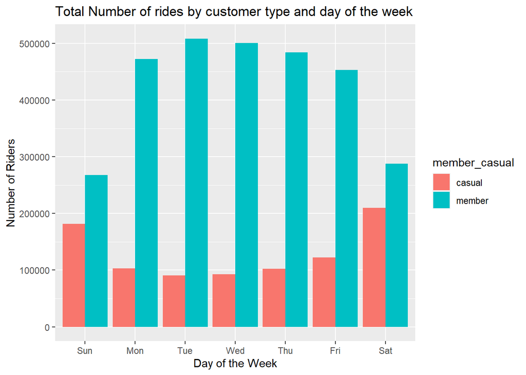

```r
all_trips_v2 %>%
  mutate(weekday = wday(started_at, label = TRUE)) %>%
  group_by(member_casual, weekday) %>%
  summarise(number_of_rides = n()
            ,average_duration = mean(ride_length)) %>%
  arrange(member_casual, weekday)  %>%
  ggplot(aes(x = weekday, y = number_of_rides, fill = member_casual)) +
  geom_col(position = "dodge") +
  scale_y_continuous(labels = function(x) format(x, scientific = FALSE))+
  labs(title = "Total Number of rides by customer type and day of the week", y= "Number of Riders", x= "Day of the Week")
```

Seems like members use the bikes during the week, less on weekends and causal are the exact opposite.

Lets create a visual based on average ride duration

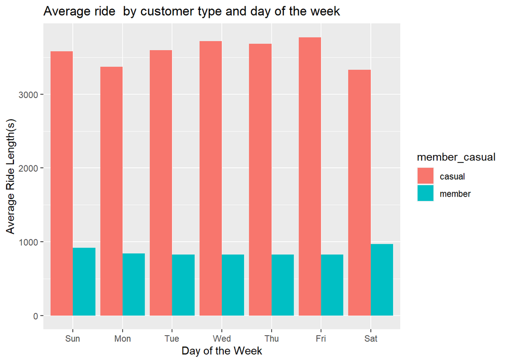

```r
all_trips_v2 %>%
  mutate(weekday = wday(started_at, label = TRUE)) %>%
  group_by(member_casual, weekday) %>%
  summarise(number_of_rides = n()
            ,average_duration = mean(ride_length)) %>%
  arrange(member_casual, weekday)  %>%
  ggplot(aes(x = weekday, y = average_duration, fill = member_casual)) +
  geom_col(position = "dodge")+
  labs(title = "Average ride  by customer type and day of the week", x= "Day of the Week", y= "Average Ride Length(s)")
```

So it’s clear the average ride time for casuals is higher than members on every day of the week. There could be reasons for this, but lets consider the month of the year and see if anything else comes to light.

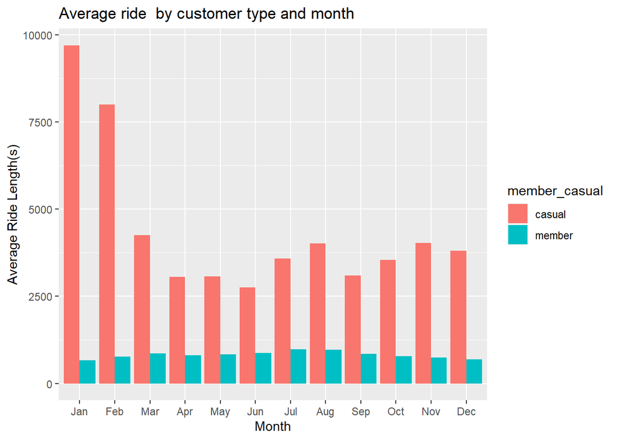

```r
all_trips_v2 %>%
  mutate(month = month(started_at, label = TRUE)) %>%
  group_by(member_casual, month) %>%
  summarise(average_duration = mean(ride_length)) %>%
  arrange(member_casual, month)  %>%
  ggplot(aes(x = month, y = average_duration, fill = member_casual)) +
  geom_col(position = "dodge")+
  labs(title = "Average ride  by customer type and month", x= "Month", y= "Average Ride Length(s)")
```

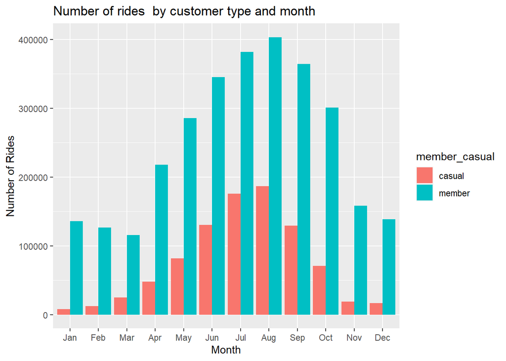

```r
all_trips_v2 %>%
  mutate(month = month(started_at, label=TRUE)) %>%
  group_by(member_casual, month) %>%
  summarise(number_of_rides = n()) %>%
    arrange(member_casual, month)  %>%
  ggplot(aes(x = month, y = number_of_rides, fill = member_casual)) +
  geom_col(position = "dodge")+
  scale_y_continuous(labels = function(x) format(x, scientific = FALSE))+
  labs(title = "Number of rides  by customer type and month", x= "Month", y= "Number of Rides")
```

So it seems the average ride duration is higher for the casuals all year round, but their is more consistent number of rides for members year round. With the summer months being more popular for both customer types, which makes with the snow in the winter months. It also seems to be the case that members are more consistent throughout the year which may indicate them using the bikes to commute to work. Lets the the average start times and see if this is the case.

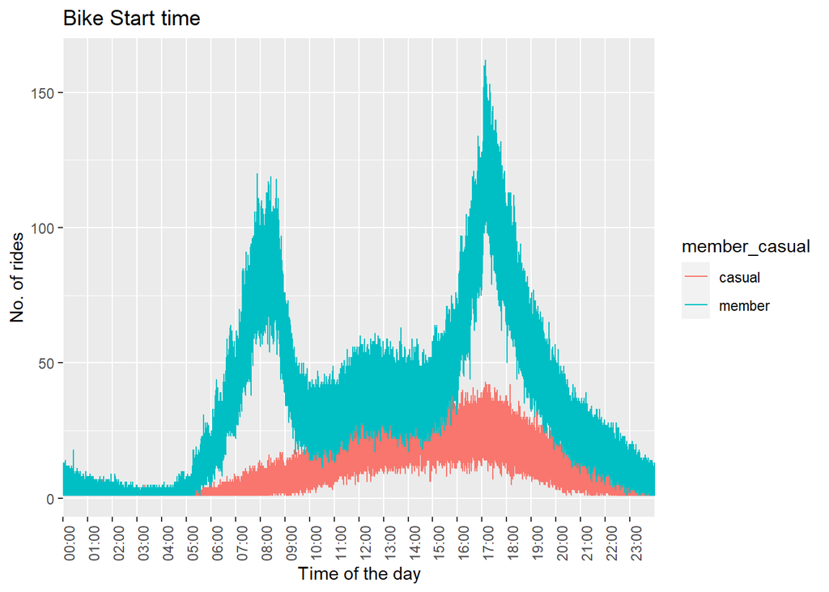

```r
all_trips_v2 %>%
  group_by(member_casual, start_time) %>%
  summarise(number_of_rides = n()) %>%
ggplot(aes(x = start_time, y = number_of_rides, color = member_casual, group = member_casual))+
  geom_line() +
  scale_x_datetime(date_breaks = "1 hour", minor_breaks = NULL,
                   date_labels = "%H:%M", expand = c(0,0))+
  labs(title ="Bike Start time", x = "Time of the day", y = "No. of rides")+
  theme(axis.text.x = element_text(angle = 90))
```

# Act It appears members are taking out bikes mostly from 7-9 am and the again from 4-7 pm. This would back up the prediction of members using the bikes to commute to work. The casuals use the bikes mostly from 4-7 pm, similar to members, but no influx in the morning. This may suggest casuals using the bikes as an outlet for exercise. THe members may be doing this as well.

So there was a lot of information we have gathered here.

**Casuals**- Rides tend to be longer and during the warmer months. Hot times for casuals are from 4-7pm. This hints to using the bikes for exercise and for leisure.

**Members**- Rides are shorter than casuals and are consistent throughout the year (yes it is still higher during the warmer months). Hot times for the members are from 7-9 am and 4-7 pm. This indicates members are using the bikes as a means of transportation to commute to work.

Since the goal of the stakeholders was to understand how to convert casuals to members in order to maximize their profit. This could be done in numerous ways. Perhaps advertising in high density areas like subways and bus stops to show how people can use the bikes as a means to commute to work. Perhaps its saving money, like it’s cheaper than public transit or cheaper than a gym membership will convert the casual.

These options would be presented to the stakeholders but the analysis is primarily for them to understand how casuals and members use the bikes differently.

# Extension Analaysis for Stake Holders

Possibility for further exploration would be to check the stations that are popular with members, with casuals, and the ones that are not. This may give the stake holders a better idea where their members are using their bikes and to see if there are high traffic areas with more casuals than members.

```r
all_trips_v2 %>%
 group_by( start_station_name, end_station_name, member_casual) %>%
  summarise(number_of_rides = n()   ) %>%
  arrange (start_station_name, end_station_name, member_casual)
 all_trips_v2 %>%
 group_by( start_station_name, end_station_name ) %>%
  summarise(number_of_rides = n()   ) %>%
  arrange (desc(number_of_rides))
#write.csv(station_data, file= "C:/Users/baleo/OneDrive/Documents/Cyclist/station_traffic_data.csv")
```

[output not shown]